# EPSY 5122

## Programming for Social Science Researchers

## Assignment 11

### Due Thursday, December 7, 2023 by 1pm

## Hanna Yu

#### Problem 0

If you've made it to this document, you likely already did Problem 0 from the readme. But just in case, here it is again!

a) Let's watch some videos! I recommend all the videos in this series (for future learning), but we will just focus on two now. Watch the first half of this video (https://www.youtube.com/watch?v=_NrSWLQsDL4&list=PLRqwX-V7Uu6ZF9C0YMKuns9sLDzK6zoiV&index=3) -- just the part about forking, you can ignore pull requests! Then watch this video: https://www.youtube.com/watch?v=yXT1ElMEkW8&list=PLRqwX-V7Uu6ZF9C0YMKuns9sLDzK6zoiV&index=6 (you don't have to do the terminal git commands, you can use the GitKraken clone strategy we used in class)

b) Using what you learned in 0a, fork this GitHub repository (remote repo) to your own GitHub account, then **clone your forked repo** (not my repo!) to your hard drive (local repo) using VSCode or GitKraken (or use the command-line in terminal if you want the extra challenge). After finishing EACH problem below, make sure to STAGE and COMMIT with a comment (e.g., "Just finished Part 1! Git is fun!" or whatever). Then PUSH back to GitHub.

###### Note on privacy!

By default, GitHub repos are public (promoting open source sharing of code), but of course you are more than welcome to make your code for this assignment private, as is your right! If you want to make your repo private instead of public, that *should* work well in VSCode. In case it doesn't (or you want to go another route), here are 3 other ways to do this privately:

1) GitKraken partners with GitHub to provide a free pack of resources (including the pro version of GitKraken) for *students*. That's you! So you can sign up here *only if you want to do this*: https://education.github.com/pack?utm_source=github+gitkraken

2) Just keep your GitHub repo public while you're working on this project. Use VSCode or free GitKraken. Then switch the GitHub repo to Private only when you're done using an app to push to GitHub.

3) Keep the repo private and use the terminal git commands in the YouTube video for Problem 0a. This will require an ssh key (more secure than https). Please see the links for how to do this in the Week 11 class materials.

To make the repo private: On your GitHub repo, go to Settings > Manage Access > Manage (under Public Repository) > Change Visibility. Then add me (jkbye) as a 'collaborator' so I can see it: Settings > Manage Access > Invite a Collaborator (green button) > add 'jkbye'.

#### Problem 1

Now let's get to Jupyter!

a) Import any helpful libraries in this Jupyter Notebook.

b) Load the included *MA_Public_Schools_2017.csv* file as a pandas data frame. Note: these data are from Kaggle: https://www.kaggle.com/ndalziel/massachusetts-public-schools-data and I have already removed a lot of columns.

c) Adapt the example code in the chunk below to replace all spaces in column names with underscores. This is good practice in order to not cause problems with functions that don't allow spaces in variable names (e.g., **smf.ols**).

d) Adapt the code from 1c to replace "%" sign with "Perc", because it is also good practice not to start column names with symbols.

e) Find the descriptives for numeric columns.

f) Commit your changes and push to GitHub!

```python
# Problem 1 a)

import numpy as np
import pandas as pd
import seaborn as sns
import matplotlib.pyplot as plt
import scipy.stats as stats
import statsmodels.formula.api as smf

# Problem 1 b)
schooldata= pd.read_csv('/Users/a12173/Desktop/Python/f23_pfssr_assignment11/in_data/MA_Public_Schools_2017.csv')
school_data = schooldata
```

```python
# Problem 1 code here (can split into multiple code chunks if you want)

# starter code for 1c -- replace school_data w/ your dataframe name
school_data.columns = school_data.columns.str.replace(' ', '_') # notice this replaces the 1st argument w/ the 2nd
```

```python
# Problem 1d
print(school_data.columns) # Check the column name
school_data.columns = school_data.columns.str.replace('%', 'Perc') # replace
```

```
Index(['School_Code', 'School_Name', 'School_Type', 'Town', 'State', 'Grade',
       'District_Name', 'District_Code', 'PreK_Enrollment', 'K_Enrollment',
       '1_Enrollment', '2_Enrollment', '3_Enrollment', '4_Enrollment',
       '5_Enrollment', '6_Enrollment', '7_Enrollment', '8_Enrollment',
       '9_Enrollment', '10_Enrollment', '11_Enrollment', '12_Enrollment',
       'SP_Enrollment', '%_First_Language_Not_English',
       '%_English_Language_Learner', '%_Students_With_Disabilities',
       '%_High_Needs', '%_Economically_Disadvantaged', '%_African_American',
       '%_Asian', '%_Hispanic', '%_White', '%_Native_American',
       '%_Native_Hawaiian,_Pacific_Islander', '%_Multi-Race,_Non-Hispanic',
       '%_Males', '%_Females', 'Average_Class_Size', 'Number_of_Students',
       'Salary_Totals', 'Average_Salary', 'FTE_Count',
       'In-District_Expenditures', 'Total_In-district_FTEs',
       'Average_In-District_Expenditures_per_Pupil', 'Total_Expenditures',
       'Total_Pupil_FTEs', 'Average_Expenditures_per_Pupil'],
      dtype='object')
```

```python
# Problem 1e

school_data.drop(['School_Code', 'District_Code'], axis=1).describe() # show descriptive stat of numeric values.
```

|  | PreK_Enrollment | K_Enrollment | 1_Enrollment | 2_Enrollment | 3_Enrollment | 4_Enrollment | 5_Enrollment | 6_Enrollment | 7_Enrollment | 8_Enrollment | ... | Number_of_Students | Salary_Totals | Average_Salary | FTE_Count | In-District_Expenditures | Total_In-district_FTEs | Average_In-District_Expenditures_per_Pupil | Total_Expenditures | Total_Pupil_FTEs | Average_Expenditures_per_Pupil |
| --- | --- | --- | --- | --- | --- | --- | --- | --- | --- | --- | --- | --- | --- | --- | --- | --- | --- | --- | --- | --- | --- |
| count | 1861.000000 | 1861.000000 | 1861.000000 | 1861.000000 | 1861.000000 | 1861.000000 | 1861.000000 | 1861.000000 | 1861.000000 | 1861.000000 | ... | 1823.000000 | 1.769000e+03 | 1769.000000 | 1769.000000 | 1.768000e+03 | 1768.000000 | 1768.00000 | 1.768000e+03 | 1768.000000 | 1768.000000 |
| mean | 15.837722 | 35.535196 | 36.629232 | 37.518538 | 38.584632 | 38.717356 | 38.089199 | 37.879635 | 38.543794 | 38.540570 | ... | 523.515634 | 5.625178e+07 | 74036.641040 | 707.853024 | 1.518097e+08 | 9376.335633 | 14573.85582 | 1.731198e+08 | 10466.072624 | 15038.254949 |
| std | 37.784512 | 44.632989 | 42.732414 | 43.842672 | 46.541783 | 48.915559 | 55.040382 | 75.304290 | 81.320657 | 82.048832 | ... | 357.861705 | 9.335788e+07 | 7990.377315 | 1065.807405 | 2.661339e+08 | 14015.732845 | 2940.80342 | 3.093057e+08 | 16287.467986 | 2743.977057 |
| min | 0.000000 | 0.000000 | 0.000000 | 0.000000 | 0.000000 | 0.000000 | 0.000000 | 0.000000 | 0.000000 | 0.000000 | ... | 2.000000 | 5.534000e+04 | 34588.000000 | 2.000000 | 6.975500e+05 | 38.400000 | 9451.51000 | 1.132413e+06 | 82.800000 | 10399.970000 |
| 25% | 0.000000 | 0.000000 | 0.000000 | 0.000000 | 0.000000 | 0.000000 | 0.000000 | 0.000000 | 0.000000 | 0.000000 | ... | 306.500000 | 1.215839e+07 | 68572.000000 | 166.000000 | 3.061598e+07 | 2312.150000 | 12785.25000 | 3.353242e+07 | 2442.900000 | 13339.700000 |
| 50% | 0.000000 | 17.000000 | 22.000000 | 20.000000 | 16.000000 | 16.000000 | 0.000000 | 0.000000 | 0.000000 | 0.000000 | ... | 445.000000 | 2.269741e+07 | 73471.000000 | 308.000000 | 5.293331e+07 | 4205.300000 | 13599.49000 | 5.863741e+07 | 4392.000000 | 14137.480000 |
| 75% | 15.000000 | 64.000000 | 66.000000 | 68.000000 | 71.000000 | 70.000000 | 66.000000 | 45.000000 | 22.000000 | 20.000000 | ... | 634.500000 | 4.808571e+07 | 78256.000000 | 627.000000 | 1.287478e+08 | 7700.400000 | 15478.08000 | 1.335444e+08 | 8378.900000 | 15900.290000 |
| max | 560.000000 | 557.000000 | 245.000000 | 250.000000 | 319.000000 | 446.000000 | 487.000000 | 490.000000 | 511.000000 | 644.000000 | ... | 4327.000000 | 3.838662e+08 | 100731.000000 | 4323.000000 | 1.093104e+09 | 56858.800000 | 38780.85000 | 1.269580e+09 | 65964.600000 | 30505.050000 |

8 rows × 40 columns

```python
#problem 1e Commit your changes and push to GitHub!
```

#### Problem 2

a) Remove the District Code column.

b) Create a new column called "TOTAL_Enrollment" that is the sum of all columns that end in "Enrollment".

c) Compute the mean of "TOTAL_Enrollment" for each District. (Hint: groupby)

d) Commit your changes and push to GitHub!

```python
# Problem 2 code here (can split into multiple code chunks if you want)

#a) Remove the District Code column.

school_data = school_data.drop(['District_Code'], axis=1)
school_data.head()
```

|  | School_Code | School_Name | School_Type | Town | State | Grade | District_Name | PreK_Enrollment | K_Enrollment | 1_Enrollment | ... | Number_of_Students | Salary_Totals | Average_Salary | FTE_Count | In-District_Expenditures | Total_In-district_FTEs | Average_In-District_Expenditures_per_Pupil | Total_Expenditures | Total_Pupil_FTEs | Average_Expenditures_per_Pupil |
| --- | --- | --- | --- | --- | --- | --- | --- | --- | --- | --- | --- | --- | --- | --- | --- | --- | --- | --- | --- | --- | --- |
| 0 | 10505 | Abington High | Public School | Abington | MA | 09,10,11,12 | Abington | 0 | 0 | 0 | ... | 451.0 | 9489496.0 | 74662.0 | 127.0 | 23365711.18 | 1939.0 | 12050.39 | 27229100.8 | 2051.8 | 13270.84 |
| 1 | 10003 | Beaver Brook Elementary School | Public School | Abington | MA | 01,02,03,04 | Abington | 0 | 0 | 125 | ... | 643.0 | 9489496.0 | 74662.0 | 127.0 | 23365711.18 | 1939.0 | 12050.39 | 27229100.8 | 2051.8 | 13270.84 |
| 2 | 10002 | Center Elementary School | Public School | Abington | MA | PK,K | Abington | 69 | 134 | 0 | ... | 208.0 | 9489496.0 | 74662.0 | 127.0 | 23365711.18 | 1939.0 | 12050.39 | 27229100.8 | 2051.8 | 13270.84 |
| 3 | 10405 | Frolio Middle School | Public School | Abington | MA | 07,08 | Abington | 0 | 0 | 0 | ... | 342.0 | 9489496.0 | 74662.0 | 127.0 | 23365711.18 | 1939.0 | 12050.39 | 27229100.8 | 2051.8 | 13270.84 |
| 4 | 10015 | Woodsdale Elementary School | Public School | Abington | MA | 05,06 | Abington | 0 | 0 | 0 | ... | 334.0 | 9489496.0 | 74662.0 | 127.0 | 23365711.18 | 1939.0 | 12050.39 | 27229100.8 | 2051.8 | 13270.84 |

5 rows × 47 columns

```python
#b) Create a new column called "TOTAL_Enrollment" that is the sum of all columns that end in "Enrollment".

school_data['TOTAL_Enrollment']=school_data.iloc[:,8:22].sum(axis=1) # It added all values up and created a clolum

#axis=0: This is the default. It sums down the rows for each column. In other words, it gives you the sum of each column separately.
#axis=1: This sums across the columns for each row. It gives you the sum of all values in a row across the specified colum

school_data.head()
```

|  | School_Code | School_Name | School_Type | Town | State | Grade | District_Name | PreK_Enrollment | K_Enrollment | 1_Enrollment | ... | Salary_Totals | Average_Salary | FTE_Count | In-District_Expenditures | Total_In-district_FTEs | Average_In-District_Expenditures_per_Pupil | Total_Expenditures | Total_Pupil_FTEs | Average_Expenditures_per_Pupil | TOTAL_Enrollment |
| --- | --- | --- | --- | --- | --- | --- | --- | --- | --- | --- | --- | --- | --- | --- | --- | --- | --- | --- | --- | --- | --- |
| 0 | 10505 | Abington High | Public School | Abington | MA | 09,10,11,12 | Abington | 0 | 0 | 0 | ... | 9489496.0 | 74662.0 | 127.0 | 23365711.18 | 1939.0 | 12050.39 | 27229100.8 | 2051.8 | 13270.84 | 452 |
| 1 | 10003 | Beaver Brook Elementary School | Public School | Abington | MA | 01,02,03,04 | Abington | 0 | 0 | 125 | ... | 9489496.0 | 74662.0 | 127.0 | 23365711.18 | 1939.0 | 12050.39 | 27229100.8 | 2051.8 | 13270.84 | 580 |
| 2 | 10002 | Center Elementary School | Public School | Abington | MA | PK,K | Abington | 69 | 134 | 0 | ... | 9489496.0 | 74662.0 | 127.0 | 23365711.18 | 1939.0 | 12050.39 | 27229100.8 | 2051.8 | 13270.84 | 134 |
| 3 | 10405 | Frolio Middle School | Public School | Abington | MA | 07,08 | Abington | 0 | 0 | 0 | ... | 9489496.0 | 74662.0 | 127.0 | 23365711.18 | 1939.0 | 12050.39 | 27229100.8 | 2051.8 | 13270.84 | 328 |
| 4 | 10015 | Woodsdale Elementary School | Public School | Abington | MA | 05,06 | Abington | 0 | 0 | 0 | ... | 9489496.0 | 74662.0 | 127.0 | 23365711.18 | 1939.0 | 12050.39 | 27229100.8 | 2051.8 | 13270.84 | 353 |

5 rows × 48 columns

```python
#c) Compute the mean of "TOTAL_Enrollment" for each District. (Hint: groupby)

school_data.groupby("District_Name")['TOTAL_Enrollment'].mean() #groupby should come first

#d) Commit your changes and push to GitHub!
```

```
District_Name
Abby Kelley Foster Charter Public (District)            1425.000000
Abington                                                 369.400000
Academy Of the Pacific Rim Charter Public (District)     527.000000
Acton-Boxborough                                         610.111111
Acushnet                                                 452.500000
                                                           ...
Winthrop                                                 479.250000
Woburn                                                   407.636364
Worcester                                                537.355556
Worthington                                               49.000000
Wrentham                                                 471.500000
Name: TOTAL_Enrollment, Length: 410, dtype: float64
```

#### Problem 3

a) Visualize each bivariate relationship among Average_Class_Size, Average_Salary, Perc_Economically_Disadvantaged, and Perc_English_Language_Learner. Use the Seaborn function **pairplot**. The argument to `pairplot` should be `school_data[['Average_Class_Size', 'Average_Salary', 'Perc_Economically_Disadvantaged', 'Perc_English_Language_Learner']]`, which will just pull those columns out from the full data frame.

b) Describe what you see from the plots.

c) Based on your observations from 3b, and as a completely post-hoc, exploratory analysis, choose one of the 4 measures from 3a to be an outcome variable, and a second measure to be a predictor variable. Then run a linear regression, print the *summary*, and write a sentence interpreting the results (does not need to be detailed, just practice retrieving the relevant info on predictor significance, etc.)

d) Commit your changes and push to GitHub!

```python
# Problem 3 code here (can split into multiple code chunks if you want)
```

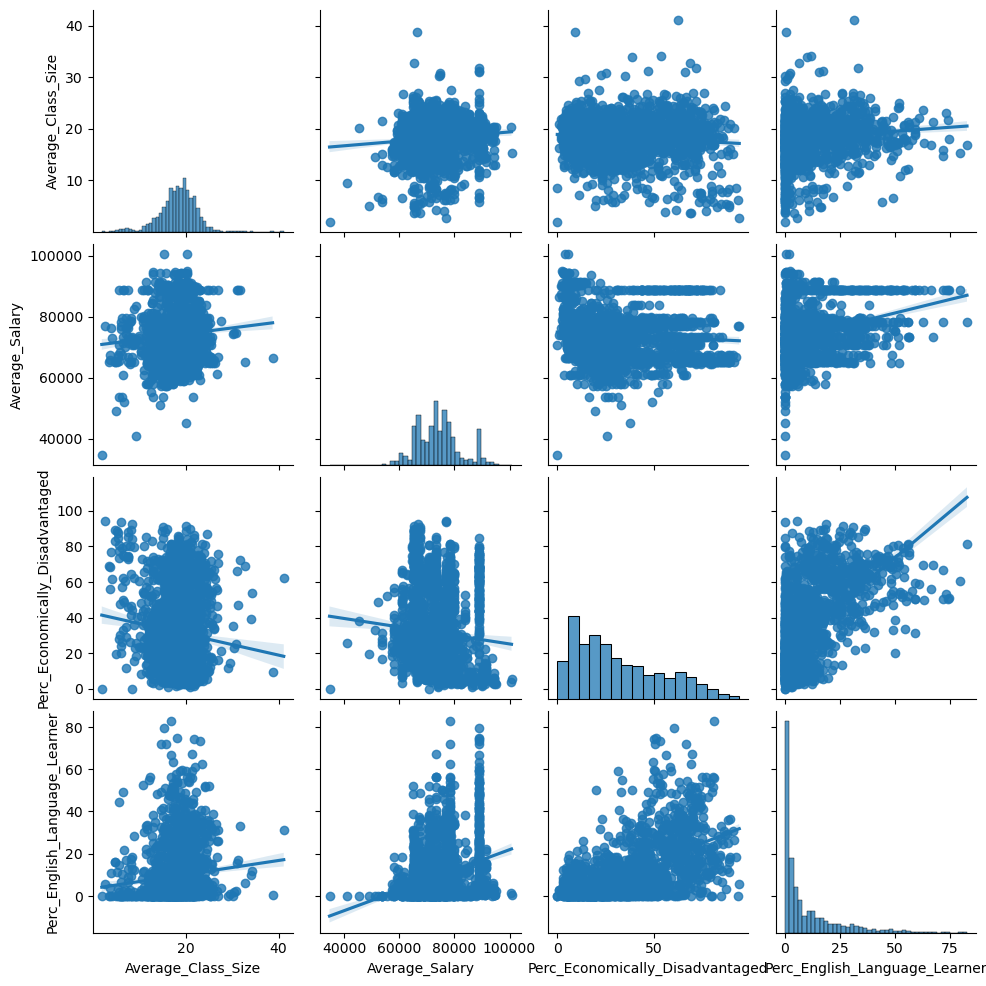

```python
#problem 3a

Plot = sns.pairplot(school_data[['Average_Class_Size', 'Average_Salary', 'Perc_Economically_Disadvantaged', 'Perc_English_Language_Learner']], kind='reg')
# kind shows bivrate relationsihp between two variables
```

```python
#problem 3b

#1 Average_class_size
#Average class size has a trivial positive relationship with the average salary of teachers and the percentage of English learners.
#Average class size has a trivial negative relationship with the percentage of economically disadvantaged students.

#2 Average_salary
#The average salary of teachers has a positive relationship with the average class size and the percentage of English learners (but this is uncertain, as there is a consistent group of teachers who receive the same payment regardless of the number of multilingual students).

#3 Percentage Economically Disadvantaged Group
#The percentage of the Economically Disadvantaged group has a negative association with the average salary of teachers and the average class size.
#The percentage of the Economically Disadvantaged group has a positive relationship with the percentage of English language learners.

#4 Percentage English Language Learner
#The percentage of English language learners has a positive relationship with the average class size and the average salary of teachers.
```

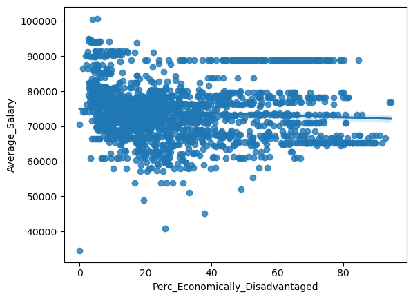

```python
#problem 3c

sns.regplot (x =school_data['Perc_Economically_Disadvantaged'], y= school_data['Average_Salary'])
```

```python
lm  = smf.ols('Average_Salary ~ Perc_Economically_Disadvantaged',school_data).fit()
lm.summary()
```

OLS Regression Results

| Dep. Variable: | Average_Salary | R-squared: | 0.007 |
| --- | --- | --- | --- |
| Model: | OLS | Adj. R-squared: | 0.007 |
| Method: | Least Squares | F-statistic: | 12.76 |
| Date: | Mon, 11 Dec 2023 | Prob (F-statistic): | 0.000364 |
| Time: | 21:59:02 | Log-Likelihood: | -18389. |
| No. Observations: | 1768 | AIC: | 3.678e+04 |
| Df Residuals: | 1766 | BIC: | 3.679e+04 |
| Df Model: | 1 |  |  |
| Covariance Type: | nonrobust |  |  |

|  | coef | std err | t | P>\|t\| | [0.025 | 0.975] |
| --- | --- | --- | --- | --- | --- | --- |
| Intercept | 7.499e+04 | 325.809 | 230.151 | 0.000 | 7.43e+04 | 7.56e+04 |
| Perc_Economically_Disadvantaged | -30.1463 | 8.440 | -3.572 | 0.000 | -46.700 | -13.593 |

| Omnibus: | 32.489 | Durbin-Watson: | 0.450 |
| --- | --- | --- | --- |
| Prob(Omnibus): | 0.000 | Jarque-Bera (JB): | 39.987 |
| Skew: | 0.250 | Prob(JB): | 2.07e-09 |
| Kurtosis: | 3.541 | Cond. No. | 66.4 |

Notes:  
[1] Standard Errors assume that the covariance matrix of the errors is correctly specified.

```python
# A one percent increase in the proportion of economically disadvantaged students is significantly associated with a $30 decrease in the average salary of teachers (p ≤ 0.001).
```

#### Problem 4

a) Create a new linear regression model that takes the model from 3c and adds both of the remaining variables from 3a as additional predictor variables. To do this, the formula interface would look like `"outcome_name ~ predictor1_name + predictor2_name + predictor3_name"`

b) Print the summary from 4a, and write a short interpretation of the results, especially comparing it to Problem 3c.

c) Add School_Type as another predictor to your model. Interpret the new predictor in your output. How is it different from the other predictors?

d) Commit your changes and push to GitHub!

```python
# Problem 4 code here (can split into multiple code chunks if you want)
```

```python
#Problem 4 a

lm1  = smf.ols('Average_Salary ~ Perc_Economically_Disadvantaged + Average_Class_Size + Perc_English_Language_Learner' ,school_data).fit()
```

```python
lm1.summary()

# Complared to model 1, model 2 has two significant variagles: Perc_Economically_Disadvantaged and Perc_English_Language_Learner
# A one percent increase in the percentage of economically disadvantaged students is significantly associated with a $154 decrease in the average salary of teachers (p ≤ 0.001).
# A one percent increase in the percentage of English language learner is significantly associated with a $342 increase in the average salary of teachers (p ≤ 0.001).
# The average class size is not significant in predicting the average salary of teacher (p > 0.05).
```

OLS Regression Results

| Dep. Variable: | Average_Salary | R-squared: | 0.200 |
| --- | --- | --- | --- |
| Model: | OLS | Adj. R-squared: | 0.199 |
| Method: | Least Squares | F-statistic: | 145.0 |
| Date: | Mon, 11 Dec 2023 | Prob (F-statistic): | 7.56e-84 |
| Time: | 22:16:10 | Log-Likelihood: | -17947. |
| No. Observations: | 1743 | AIC: | 3.590e+04 |
| Df Residuals: | 1739 | BIC: | 3.592e+04 |
| Df Model: | 3 |  |  |
| Covariance Type: | nonrobust |  |  |

|  | coef | std err | t | P>\|t\| | [0.025 | 0.975] |
| --- | --- | --- | --- | --- | --- | --- |
| Intercept | 7.618e+04 | 927.258 | 82.160 | 0.000 | 7.44e+04 | 7.8e+04 |
| Perc_Economically_Disadvantaged | -154.0529 | 9.987 | -15.425 | 0.000 | -173.641 | -134.465 |
| Average_Class_Size | -27.3854 | 46.082 | -0.594 | 0.552 | -117.768 | 62.997 |
| Perc_English_Language_Learner | 341.5305 | 16.980 | 20.114 | 0.000 | 308.228 | 374.833 |

| Omnibus: | 60.939 | Durbin-Watson: | 0.716 |
| --- | --- | --- | --- |
| Prob(Omnibus): | 0.000 | Jarque-Bera (JB): | 121.750 |
| Skew: | 0.231 | Prob(JB): | 3.65e-27 |
| Kurtosis: | 4.209 | Cond. No. | 234. |

Notes:  
[1] Standard Errors assume that the covariance matrix of the errors is correctly specified.

#### Problem 5

a) Save this Jupyter notebook as an HTML file (File > Download As > HTML) into your local repository (this folder). By default, Jupyter may put your HTML file in your default Downloads folder (wherever that is) -- if that happens, just manually move the file into this repo folder.

b) Stage, commit, and push all changes to your GitHub repository.

c) Submit a link to your repository as your submission for the assignment on Canvas. Remember the note from Problem 0: you can keep your repo private and add me as a collaborator.

#### Problem 6

Write a paragraph or so on how things are going with your final project.

#### Problem 7

Drink some water, get some rest, take care of yourself. You're almost done with the semester!

```python
#school_data['TOTAL_Enrollment']=school_data.iloc[:,8:22].sum(axis=1)
#axis=0: This is the default. It sums down the rows for each column. In other words, it gives you the sum of each column separately.
#axis=1: This sums across the columns for each row. It gives you the sum of all values in a row across the specified colum
```